# Differential gene expression DESeq2 of lung cancer and healthy patients

Elena Melnik

10 07 2021

This tutorial was made as part of the lessons “Differential gene expression” from GenomicsUa (https://www.youtube.com/watch?v=uV63nZWDB2U&ab_channel=NGOGenomicsUA)

Task: To determine which genes are expressed more strongly (RNASeq data analysis)

# Introduction

Quantitative analysis of gene expression - analysis of the transcriptome, measurement of the transcriptional activity of a gene by determining the amount of its product, messenger RNA (mRNA), which is universal for most genes.

Expression Quantification with RNA-Seq As a result of RNA sequencing, a library of reads (or a library of reads) is created. First, the length of the read is determined from 25 to 200 nucleotides, depending on the selected sequencing method. Then the reads are mapped (or aligned) to the reference genome. Reads can be aligned to several genome regions at once or to different isoforms of the same gene.

As a result of the NGS analysis, we obtain raw data using the HTSeq software.

HTSeq A simple approach that counts the number of reads that intersect with a given genome. At the same time, the program contains various definitions of the intersection of a read with a gene.

This program allows us to get a quantitative signal or number of reads for each gene. We combine the number of reads for each sample into a table. And this table is further analyzed using differential gene expression analysis.

Models It is recognized that obtaining a reliable estimate of the variance parameter for each gene is critical for the analysis of expression indicators, and a lot of efforts have been concentrated in this direction. However, obtaining this is complicated by the small selection in most RNA-seq experiments, which motivates sharing information between genes for more accurate estimates. The first assumption was to assume that the variance parameter is the same for all genes, which allows it to be used using all the original data using the conditional extreme likelihood method. DESeq, edgeR, NBPSeq use gene data separation to estimate variance, are in the method. EdgeR uses a less restrictive approach - the variance of the definition for each gene, but individual estimates are “squeezed” to the total variance by the weighted likelihood method dgeR.

Most of the model parameters (baySeq, DESeq, edgeR, and NBPSeq) use the inverse binomial distribution model to explain the excess variance.

DESeq, edgeR, NBPSeq use the classic hypothesis testing approach. DESeq and NBPSeq derive an estimate of variance by modeling the observed relationship between mean and variance by parametric regression. DESeq uses a conservative approach - choose the largest value of the variance (from the estimate with the separation of information about other genes and estimate the variance for an individual gene).

It makes no sense to use the Poisson distribution because of the large variance, and in this case, it is the binomial negative one that is relevant.

Negative binomial distribution is a good fit for RNA-Seq data and flexible enough to account for biological variability.

DESeq Differential gene expression from count data based on negative binomial distribution. Offers two transformations for stabilizing the variance of count data - VST - Variance stabilizing Transformation - Regularizes log (rlog)

The raw data mustn’t be normalized before analysis since the normalization itself occurs in the program algorithm.

DESeq2 - Read counts associated with genes - Quality control Normalization Unsupervised clustering analyses - DE analysis Modeling raw counts for each gene Shrinking log2 fold changes Testing for differential expression

Downloading the necessary packages and libraries for analysis

```r
if (!requireNamespace("BiocManager", quietly = TRUE))
   install.packages("BiocManager")
  BiocManager::install((c('DESeq2', 'genefilter')))
```

```r
#install.packages(gplots)
library(DESeq2)
library(gplots)
library( "RColorBrewer")
library("genefilter")
```

The NCI Genomic Data Commons database of lung cancer patients has been made publicly available here https://portal.gdc.cancer.gov/repository The file “Conditions” describes which samples are malignant and which are normal.

```r
countData <- as.matrix(read.csv("LUSC_NORM.csv",row.names=2))
countData = countData[,c(2:10)]
colData <- read.csv("Conditions.csv", row.names=1)
all(rownames(colData) %in% colnames(countData))
```

```
## [1] TRUE
```

We get a composite dataset from raw gene expression data and a table that describes the samples. The resulting object can be used in other packages from Bioconductor.

Сreation a table with a new data type and perform a logarithmic transformation. In biostatistics, data are usually normalized logarithmically to reduce variance.

p-value and p.adjust are used to determine the significant difference in different samples

```r
#create a new object to store information
dds <- DESeqDataSetFromMatrix(countData = countData, colData = colData, design=~condition, ignoreRank = TRUE)
#Applying the main function of this package to estimate statistical parameters
dds <- DESeq(dds)
#Filter out genes with less than 10 reads
keep <- rowSums(counts(dds)) >= 10
dds <- dds[keep, ]

#Extract results: p-values, p.adjust
res <- results(dds)

#what types of data are left
mcols(res, use.names=TRUE)
```

```
## DataFrame with 6 rows and 2 columns
##                        type            description
##                 <character>            <character>
## baseMean       intermediate mean of normalized c..
## log2FoldChange      results log2 fold change (ML..
## lfcSE               results standard error: cond..
## stat                results Wald statistic: cond..
## pvalue              results Wald test p-value: c..
## padj                results   BH adjusted p-values
```

Setting the threshold and see how much of the given data is in object.

Depending on the problem, we choose a more or less stringent selection condition using p.adjust. The smaller this value, the smaller the sample of genes.

The average amount of normalized signal per gene. The point is the gene. The x-axis is the mean of normalized counts. The y-axis is the estimated variance. The variance of poorly expressed genes is higher.

```r
#the number of genes at different p-values
sum(res$pvalue < 0.05, na.rm=TRUE)
```

```
## [1] 11390
```

```r
sum(res$padj < 0.1, na.rm=TRUE)
```

```
## [1] 10337
```

```r
sum(res$padj < 0.01, na.rm=TRUE)
```

```
## [1] 5468
```

```r
#selection only those genes with the p-value < 0.01
resSig <- res[which(res$padj < 0.01 ), ]

head(resSig)
```

```
## log2 fold change (MLE): condition normal vs cancer
## Wald test p-value: condition normal vs cancer
## DataFrame with 6 rows and 6 columns
##                     baseMean log2FoldChange     lfcSE      stat      pvalue
##                    <numeric>      <numeric> <numeric> <numeric>   <numeric>
## ENSG00000000460.15   664.975      -2.401250  0.405989  -5.91458 3.32732e-09
## ENSG00000000938.11  2013.376       3.268780  0.517296   6.31898 2.63303e-10
## ENSG00000001084.9  16885.996      -4.182596  0.652994  -6.40526 1.50111e-10
## ENSG00000001626.13   853.857       3.290102  1.031541   3.18950 1.42518e-03
## ENSG00000003436.13  6584.531       3.487093  0.662255   5.26549 1.39819e-07
## ENSG00000004142.10  6703.206      -0.791393  0.232300  -3.40677 6.57361e-04
##                           padj
##                      <numeric>
## ENSG00000000460.15 1.00298e-07
## ENSG00000000938.11 9.67108e-09
## ENSG00000001084.9  5.69826e-09
## ENSG00000001626.13 8.26790e-03
## ENSG00000003436.13 2.86340e-06
## ENSG00000004142.10 4.38088e-03
```

```r
tail(resSig[order(resSig$log2FoldChange ), ])
```

```
## log2 fold change (MLE): condition normal vs cancer
## Wald test p-value: condition normal vs cancer
## DataFrame with 6 rows and 6 columns
##                      baseMean log2FoldChange     lfcSE      stat      pvalue
##                     <numeric>      <numeric> <numeric> <numeric>   <numeric>
## ENSG00000072657.7     211.635        8.72356  0.704118  12.38934 2.98485e-35
## ENSG00000204305.12  53884.014        8.83788  0.590381  14.96979 1.15694e-50
## ENSG00000148677.6    1729.193        9.02359  0.801382  11.26003 2.06677e-29
## ENSG00000168484.11 530005.647        9.09557  1.377292   6.60395 4.00340e-11
## ENSG00000203878.10    446.952        9.50539  1.934068   4.91471 8.89123e-07
## ENSG00000235584.2     838.865       10.93108  1.144765   9.54876 1.31264e-21
##                           padj
##                      <numeric>
## ENSG00000072657.7  7.02496e-32
## ENSG00000204305.12 1.76989e-46
## ENSG00000148677.6  2.10783e-26
## ENSG00000168484.11 1.67792e-09
## ENSG00000203878.10 1.46256e-05
## ENSG00000235584.2  3.37492e-19
```

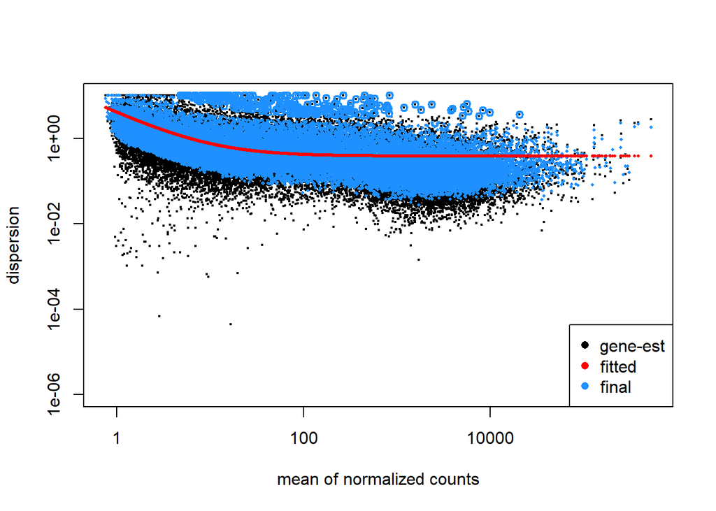

```r
#Estimated variance plot
plotDispEsts(dds, ylim = c(1e-6, 1e1))
```

Ploting the change in each gene between two categories: malignant and normal.

The line in the middle of the graph indicates the location of genes that remain unchanged, and moving up or down from it indicates more or less strong expression.

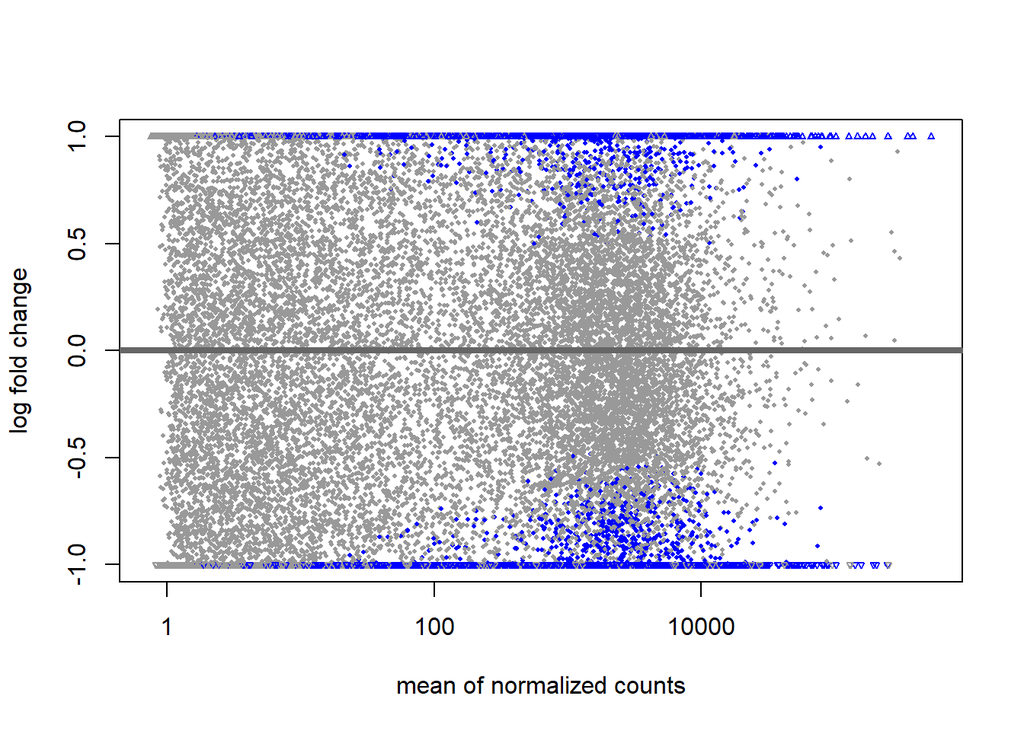

```r
plotMA(res, ylim = c(-1,1))
```

Logarithmic data transformation for plotting and PCA. Convenience for further visualization.

The plot of untransformed data shows the linear relationship between malignant samples.

```r
# rld - S4 object
rld <- rlog(dds)

head(assay(rld))
```

```
##                         LUSC1      LUSC2      LUSC3      LUSC4       LUSC5
## ENSG00000000003.13 11.5591938 12.1331232 11.4687413 11.4018994 11.33862583
## ENSG00000000005.5   0.7282237  0.4174867  0.5367423  0.3290279 -0.01891713
## ENSG00000000419.11 10.8982830 11.4643394 11.2021082 10.8452884 10.24241329
## ENSG00000000457.12  9.6195168 10.0629043 10.0738962  9.5986940  9.81630760
## ENSG00000000460.15  9.8941063  9.8533287  9.4656447  8.8328285  9.85228973
## ENSG00000000938.11  8.9274729  9.3026780  9.6546872  9.4993148  8.50569724
##                         LUSC6     NORM1     NORM2     NORM3
## ENSG00000000003.13 11.2647548 11.401541 11.005632 10.544863
## ENSG00000000005.5  -0.1104723  1.066104  2.738591  1.051984
## ENSG00000000419.11 11.2125652 10.278350 11.130801 10.463125
## ENSG00000000457.12 10.1029146  9.898123  9.945852  9.626169
## ENSG00000000460.15  9.3148976  8.025822  8.051642  7.882250
## ENSG00000000938.11  9.8221303 11.338267 11.502666 12.115345
```

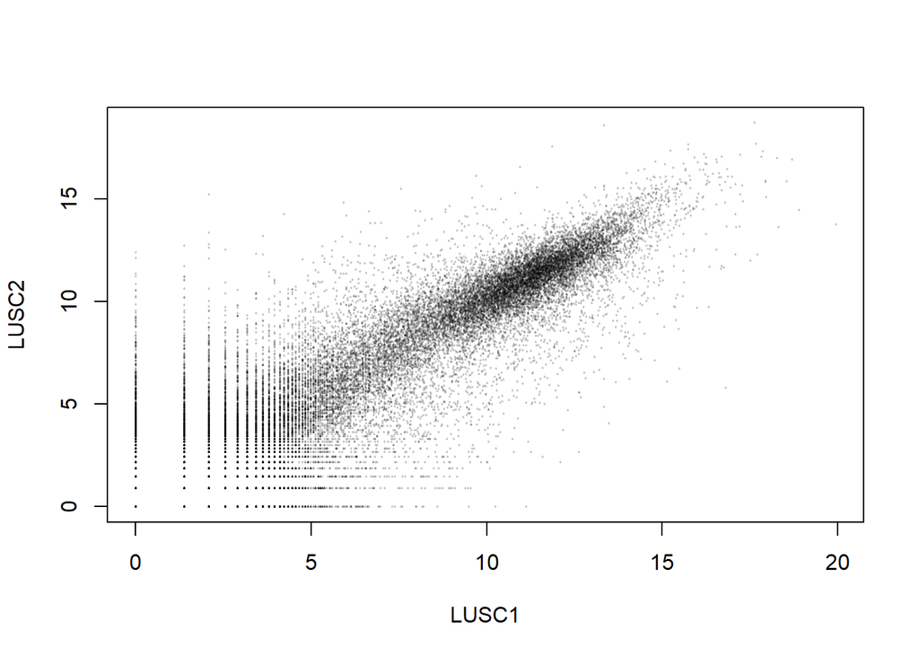

```r
#plotting the dependence of the genes of one sample on another
plot(log2( 1+counts(dds, normalized=TRUE)[, 1:2]), col="#00000020", pch=20, cex=0.3)
```

The plot of the optimized data after transformation shows a decrease in variance. The same expression appears in both datasets since we have the same type of cancer data.

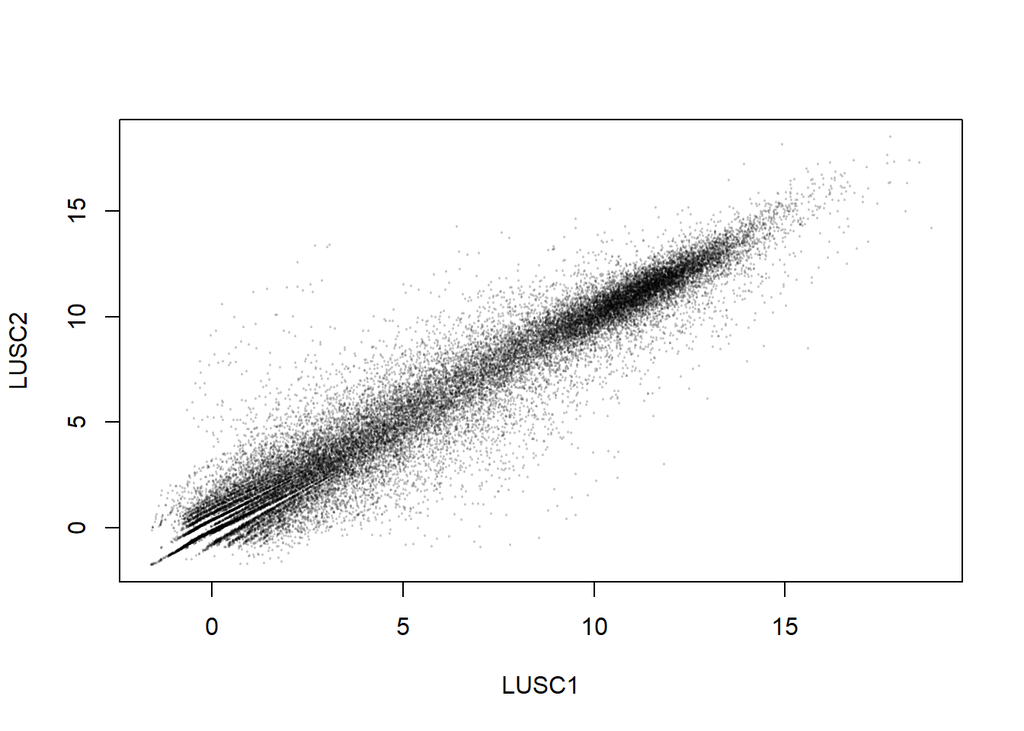

```r
#decreasing in variance
plot(assay(rld)[, 1:2], col="#00000020", pch=20, cex=0.3)
```

Estimating the distance between samples. Differentiation between the performances of the samples using Euclidean distance.

```r
sampleDists <- dist(t(assay(rld)))
sampleDists
```

```
##          LUSC1    LUSC2    LUSC3    LUSC4    LUSC5    LUSC6    NORM1    NORM2
## LUSC2 226.3398
## LUSC3 201.9735 212.3114
## LUSC4 187.4924 203.0365 154.5807
## LUSC5 184.1730 224.3558 185.6819 173.2674
## LUSC6 206.7495 216.2410 182.1451 160.6046 195.4034
## NORM1 283.5256 245.5956 240.0817 236.9196 284.7493 238.2884
## NORM2 276.5510 231.9572 237.9664 234.1988 276.2445 237.8735 135.5196
## NORM3 279.5444 245.5481 247.7161 237.5620 277.7531 238.3395 123.1359 131.5290
```

```r
#the resulting object is expressed as a matrix
sampleDistMatrix <- as.matrix(sampleDists)

# visualization of the matrix, the names of the samples are malignant or conventional
rownames(sampleDistMatrix) <- paste( rld$condition)
colnames(sampleDistMatrix) <- NULL
```

Identifying colors using different shades of blue. Building a heat map.

The distance between cancerous and normal specimens is large. Clustering samples, building a dendrogram, combining the closest samples.

On the last heat map, we can see that the samples with cancer have greater differences than the normal ones. It can be caused by different mutations or different stages of the disease.

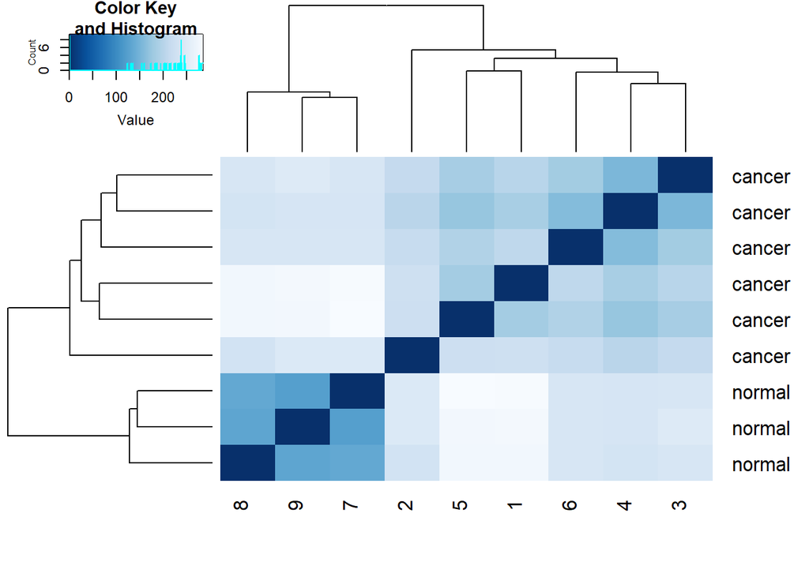

```r
colours = colorRampPalette( rev(brewer.pal(9, "Blues")) )(255)
heatmap.2( sampleDistMatrix, trace="none", col=colours)
```

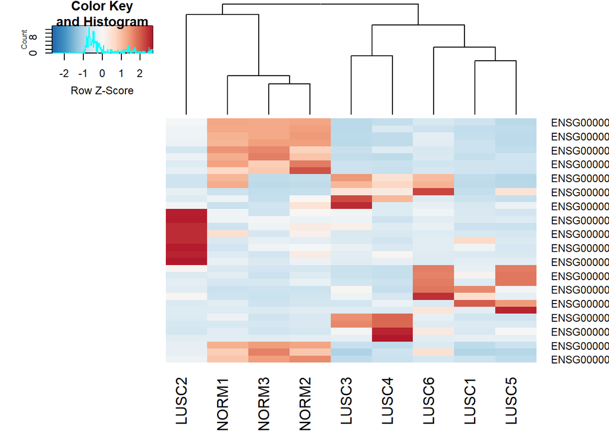

```r
#isolation of the most variable genes in samples
topVarGenes <- head(order(rowVars(assay(rld)), decreasing=TRUE), 35)

#heatmap of the 35 most variable genes for both malignant and normal specimens
colours2=colorRampPalette( rev(brewer.pal(9, "RdBu")) )(255)
heatmap.2(assay(rld)[ topVarGenes, ], scale="row", trace="none", dendrogram="column",col = colours2)
```

Multidimensional plotting of differences between samples. Identifying the differences between groups in terms of “conditions”. We can see in the graph the grouping of samples with each other, groups of normal and malignant except for 1. The outlier may be a different type of cancer sample or a damaged sample.

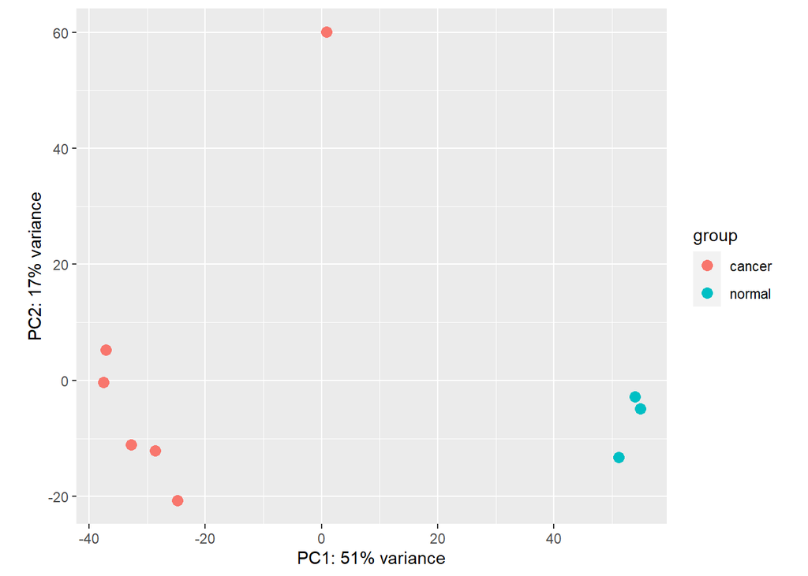

```r
#PCA - Principal component analysis
print( plotPCA(rld, intgroup = c( "condition")))
```

# Discussion